# Presentation

8 May 2017

## Introduction

## Data Analysis workflow

## Outline (1)

- Getting started like a pro
- R Dateien
- Dateimanagement
- R Markdown
- **R Markdown & Dateimanagement - Aufgabenset 0**
- Daten einlesen in R
- **Daten einlesen in R - Aufgabenset 1**
- Exkurs String Manipulation
- Merging/Joins
- **Merging/Joins - Aufgabenset 2** / **Mittagspause**

## Outline (2)

- Exkurs Pipes
- Exkurs dplyr
- **dplyr - Aufgabeset 3**
- Data Manipulation
- **Data Manipulation - Aufgabenset 4**
- Datenstrukturen und -formate
- **Datenstrukturen und -formate - Aufgabenset 5**
- Exportieren
- Abschluss & Diskussion

## Daten

- [GDELT](http://gdeltproject.org/)
- "[…] the GDELT Project monitors the world's broadcast, print, and web news from nearly every corner of every country in over 100 languages […]."
- Die Daten werden automatisiert aus den oben genannten Medien extrahiert und klassifiziert. \(\rightarrow\) Es ist möglich, dass einige Events doppelt oder sogar falsch kodiert sind.
- Beobachtungseinheit: Events mit mindestens einem Akteur.
- 58 Variablen zu den Aktueren und dem Eventtyp basierend auf der *Conflict and Mediation Event Observations* (CAMEO) Kodierung.

\(\rightarrow\) [Codebook](http://data.gdeltproject.org/documentation/CAMEO.Manual.1.1b3.pdf)

## Getting started like a pro

## Help I Need Somebody - R

> Jedes Problem wurde schon gelöst, man muss nur die Antwort finden.

### R Help

- Syntax: `?` + `function-name`
- Example: ?mean

### Vignette

- Die meisten Pakete in R bringen kurze Anleitungen mit, um die grundlegenden Funktionen anhand eines Bespiels zu erklären.
- Example: `browseVignettes("stringr")`

## Help I Need Somebody - Internet

- Am besten in `Englisch` formulieren
- Google
- Stack Overflow \(\rightarrow\) selber Fragen stellen!

## R Dateien

## R Dateien - Typen

- `.R`
- `.Rmd`
- `.RData`/`.rda`
- `.Rproj`
- `.RHistory`
- (shiny)

## Dateimanagment

## Dateimanagament - Benennung

- konsequente Benennung von Variablen
- keine Abkürzungen verwenden
- Wörter mit Unterstrich "`_`" trennen
- Datum verwenden
- Zahlenfolgen verwenden, um die Reihenfolge zu erklären
- eigenes Codebook führen, um Datensätze, Herkunft und Aktualität festzuhalten und Varibalenbezeichnungen zu erklären

## Dateimanagament - Beispiel

\(\rightarrow\) R Code kann man alternativ auch ins root Verzeichnis legen

```
.
├── _code
|   ├── _functions
|       ├── download.R
|       └── naming.R
|   ├── 00_read_data.R
|   ├── 01_data_manipulation.R
|   ├── 02_data_models.R
|   └── 03_graphics_tables.R
├── _data
|   ├── _codebooks
|       ├── mein_codebook.xlsx
|       ├── codebook_gdelt.pdf
|       └── codebook_countrycodes.xlsx
|   ├── gdelt.csv
|   └── countrycodes.xlsx
└── _graphics
    ├── boxplot_1.png
    ├── boxplot_2.png
    └── regression.png
```

## R Markdown

## R Markdown - Einführung

### Was ist Markdown?

- Markdown ist eine einfach Auszeichnungsprache (*Markup Language*) sowie \(\LaTeX\) und HTML

### Wozu braucht man das?

- RMarkdown ermöglicht es Kommentare und RCode gemeinsam zu schreiben und in einer HTML- oder PDF-Datei auszugeben.
- Sehr gut geeignet um eignen Code zu ordnen und zu beschreiben

\(\rightarrow\) sehr gut zum Reports erstellen, z.B. für den Hiwijob/Hausarbeiten

**Dieses Dokument ist auch mit RMarkdown geschrieben!**

## R Markdown - Einführung

- Überschriften

  ```
    # Überschrift 1
    ## Überschrift 2
    ### Überschrift 3
  ```

- Code Embedding

  ```
    '''{r eval=FALSE}
    v <-  1:13
    mean(v)
    '''
  ```

  \(\rightarrow\) Strg + Alt + i

## R Markdown & Data Management - Aufgabenset 0

- Erstelle eine Ordnerstruktur für das Projekt
- Lege eine RMarkdown-Datei an.
- Nenne den Titel deiner Aufgabe *Correlaid Workshop @Uni Konstanz*.
- Trage deinen Namen in das Autoren Feld ein.

### Hilfe

[RStudio - RMarkdown](http://rmarkdown.rstudio.com/authoring_basics.html)

[RMarkdown Cheat Sheet](https://www.rstudio.com/wp-content/uploads/2016/03/rmarkdown-cheatsheet-2.0.pdf)

## Exkurs Datentypen

## Exkurs Datentypen - einfache Datentypen

| Datentyp | Mögliche Werte | Beispiel |
| --- | --- | --- |
| boolean | TRUE, FALSE | `v <- false` |
| numeric | 1.2, 3, 6.5, 7, 8.9999 | `z <- 2.333` |
| integer | 1L, 2L, 3L, 99L, 0L, 77L | `i <- 3L` |
| character | 'Hallo', 'B', "CorrelAid", 'R' | `s <- "Test"` |

\(\rightarrow\) nicht vollständig!

## Exkurs Datentypen - einfache Datentypen

`fruits <- c("Banana", "Apple", "Peach", "Fries", "Tomato", "Pear")`

`animals <- c("Monkey", "Cow", "Elephant", "Rabbit", "Lion", "Cat")`

| Datentyp | Mögliche Datentypen | Beispiel |
| --- | --- | --- |
| factor | character | `as.factor(fruits)` |
| vector | boolean, numeric, integer, character | `c(1, 1, 2, 3, 5, 8)` |
| list | boolean, numeric, integer, character | `list(1, c("eins", 2, 3), "fünf")` |
| matrice | boolean, numeric, integer, character | `matrix(fruits, nrow = 2, ncol = 3, byrow = TRUE)` |
| dataframe | boolean, numeric, integer, character | `data.frame(fruits, animals)` |

\(\rightarrow\) nicht vollständig!

## Daten einlesen in R

## file endings

- jede einfache Textdatei kann eine Trennzeichen-separierte Datei sein.
- häufige Endungen
  - `.csv`
  - `.txt`
  - `.tsv`

\(\rightarrow\) können alle mit `read.csv` eingelesen werden \(\rightarrow\) URLs sind auch Pfadsysteme!

## Daten einlesen in R - csv

- csv in Text Editor angucken
- Funktionen in R
  - `read.csv` (Spezialfunktion von `read.table`)
  - (`data.table::fread`)
  - (`readr::read_csv`)

## Daten einlesen in R - read.csv

- `stringsAsFactors = FALSE` (immer!!)
- Trennzeichen: `sep = ","`
- Gibt es Variablennamen?: `header=TRUE/FALSE`
- Text qualifier: `quote = "\"'"`
- Dezimaltrenner: `dec = ","`
- Missing values: `na.strings = 99`
- File Encoding: `fileEncoding = "UTF-8"`

–> `?read.csv`

## Daten einlesen in R - xls(x)

- am besten:
  - nach csv exportieren
  - csv anschauen / Export Settings beachten
- wenns nicht anders geht (z.B. Worksheets):
  - `openxlsx` bzw. `xlsx` packages

## Daten einlesen in R - Aufgabenset 1

- Downloade das Repository von github (Link)
- Lese die csv-Dateien ein, die mit `201704` beginnen

## Exkurs String Manipulation

## Exkurs String Manipulation - Regex

- regex: reguläre Ausdrücke beschreiben Muster in Sprache
- wichtigste Elemente
  - `.` : wildcard (Joker)
  - `\d`: digit
  - `+`: vorausgegangenes Element einmal oder mehr
  - `?`: vorausgegangens Element optional
  - `{n,m} / {n}`: vorausgeganenes Element kommt mind. n und höchstens m mal vor / kommt genau n mal vor
  - `[abc]`: definiert eine Menge
- `?regex`
- zum Testen: Regex101 & RegexR

## Exkurs String Manipulation - Beispiel

- Postleitzahlen haben das Format D-xxxx(x), z.B. D-78464
- in regex:
  - `D-\d{5}` matcht alle fünfstelligen PLZ inkl. "D-"
  - `D-\d{4,5}` matcht alle vier- bis fünfstelligen PLZ inkl "D-"
  - `\d{5}`: matcht nur die fünfstelligen Zahlen
- in RegexR

## Exkurs String Manipulation - stringr

- `str_extract(_all)*`
- `str_replace(_all)*`
- `str_trim`
- `str_detect`
- `str_split`
- `str_to_lower / str_to_upper`
- *: geht auch ohne `_all`

## Merging/Joins

## Merging/Joins - Warum Merging / Joins?

### Herausforderung

- wir haben oft mehrere Datenquellen, die wir zusammenfügen müssen
- Beispiel: Umfrage-Datensatz und Länder-Datensatz, z.B. European Social Survey und Daten von Eurostat -> wollen die beiden Datensätze zusammenfügen

### Lösung

- Merge / Join

## Merging/Joins - Beispiel

- respondents

```r
print(respondents, row.names = F)
```

```
##  id    sex country
##   1   male      DE
##   2   male      DE
##   3 female      CH
##   4   male      CH
##   5 female      CH
##   6   male      FR
##   7 female      AU
```

## Merging/Joins - Beispiel

- countries

```r
print(countries, row.names = F)
```

```
##  country bip_capita
##       DE      48111
##       CH      59561
##       UK      42481
##       AU      48005
```

## Merging/Joins - dplyr joins

### dplyr join-Funktionen

- `left_join(x, y)` includes all observations in x, regardless of whether they match or not.
- `inner_join(x, y)` only includes observations that match in both x and y.
- `full_join()` includes all observations from x and y.
- …

### Ressourcen / Links

- [Vignette für dplyr Joins](https://cran.r-project.org/web/packages/dplyr/vignettes/two-table.html)
- [Visual Representation of SQL Joins](https://www.codeproject.com/articles/33052/visual-representation-of-sql-joins) ("Outer Join" = `full_join`)

## Merging/Joins - left_join(x, y)

- `left_join(x, y)` includes all observations in x, regardless of whether they match or not.

```r
r <- left_join(respondents, countries,
                         by = "country")
print(r, row.names = F)
```

```
##  id    sex country bip_capita
##   1   male      DE      48111
##   2   male      DE      48111
##   3 female      CH      59561
##   4   male      CH      59561
##   5 female      CH      59561
##   6   male      FR         NA
##   7 female      AU      48005
```

## Merging/Joins - inner_join(x, y)

- `inner_join(x, y)` only includes observations that match in both x and y.

```r
r  <- inner_join(respondents, countries,
                         by = "country")
print(r, row.names = F)
```

```
##  id    sex country bip_capita
##   1   male      DE      48111
##   2   male      DE      48111
##   3 female      CH      59561
##   4   male      CH      59561
##   5 female      CH      59561
##   7 female      AU      48005
```

## Merging/Joins - full_join(x, y)

- `full_join()` includes all observations from x and y.

```r
r <- respondents <- full_join(respondents, countries,
                         by = "country")
print(r, row.names = F)
```

```
##  id    sex country bip_capita
##   1   male      DE      48111
##   2   male      DE      48111
##   3 female      CH      59561
##   4   male      CH      59561
##   5 female      CH      59561
##   6   male      FR         NA
##   7 female      AU      48005
##  NA   <NA>      UK      42481
```

## Merging/Joins - help tables

- weitere Anwendung von joins: **Rekodierung**

### Problem

- Variable mit mehreren Ausprägungen (zuviele für `ifelse()`)

### Lösung

- Datensatz (*help table*) erstellen mit alten und neuen Ausprägungen (z.B. csv)
- in R laden
- an Originaldatensatz mergen und alte Variable löschen

## Merging/Joins - countrycode package

- verschieden Arten von Abkürzungen für Länder, z.B. DE vs. DEU vs. GER vs. 276
- `countrycode` package enthält Datensatz zum Matchen

```r
head(countrycode::countrycode_data)[, 1:7]
```

```
##        ar5 continent cowc cown eu28 eurocontrol_pru eurocontrol_statfor
## 1     ASIA      Asia  AFG  700 <NA>            Asia        Asia/Pacific
## 2 OECD1990    Europe <NA>   NA <NA>     Eurocontrol     ESRA North-West
## 3      EIT    Europe  ALB  339 <NA>     Eurocontrol           ESRA East
## 4      MAF    Africa  ALG  615 <NA>          Africa        North-Africa
## 5     ASIA   Oceania <NA>   NA <NA>            Asia        Asia/Pacific
## 6 OECD1990    Europe  AND  232 <NA>            <NA>                <NA>
```

## Merging/Joins - separate

### Problem

- "Multiple variables stored in one column" ([tidyr vignette](https://cran.r-project.org/web/packages/tidyr/vignettes/tidy-data.html))

```r
head(df, 5)
```

```
##           iso_cntry
## 1    AF-Afghanistan
## 2  AX-Aland Islands
## 3        AL-Albania
## 4        DZ-Algeria
## 5 AS-American Samoa
```

## Merging/Joins - separate

- `separate` (aus `tidyr` teilt eine character - Variable in zwei Variablen
  - an einer gegebenen Position (z.B. nach dem zweiten Character)
  - oder an einem *separator* (z.B. "-")

## Merging/Joins - separate an Position

```r
library(tidyr)
df %>% separate(col = iso_cntry, into = c("iso", "cntry"), sep = 2)
```

```
##    iso                cntry
## 1   AF         -Afghanistan
## 2   AX       -Aland Islands
## 3   AL             -Albania
## 4   DZ             -Algeria
## 5   AS      -American Samoa
## 6   AD             -Andorra
## 7   AO              -Angola
## 8   AI            -Anguilla
## 9   AQ          -Antarctica
## 10  AG -Antigua and Barbuda
```

## Merging/Joins - separate an *separator*

```r
df %>% separate(col = iso_cntry, into = c("iso", "cntry"), sep = "-")
```

```
##    iso               cntry
## 1   AF         Afghanistan
## 2   AX       Aland Islands
## 3   AL             Albania
## 4   DZ             Algeria
## 5   AS      American Samoa
## 6   AD             Andorra
## 7   AO              Angola
## 8   AI            Anguilla
## 9   AQ          Antarctica
## 10  AG Antigua and Barbuda
```

## Merging/Joins - fuzzy matching

```r
library(proxy)
ger <- c("GERMANY", "GERMNY", "GREMANY", "GERMANY", "GERMANY")
ger <- stringr::str_to_title(ger)

m <- proxy::dist(ger, countrycode_data$country.name.en, method = "Levenshtein")
dim(m)
```

```
## [1]   5 273
```

```r
countrycode_data[which(colMeans(m) == min(colMeans(m))), 1:10]
```

```
##         ar5 continent cowc cown eu28 eurocontrol_pru eurocontrol_statfor
## 89 OECD1990    Europe  GMY  255   EU     Eurocontrol     ESRA North-West
##    fao fips105  icao
## 89  79      GM E[DT]
```

## Merging/Joins - Aufgabenset 2

1. Lese die Spaltennamen ein von folgendem URL: http://bit.ly/2rb28Hi.
2. Lese alle Dateien in `data/codes` ein und merge sie an den Datensatz. Beachte dabei die unterschiedlichen Dateiformate und Trennzeichen.
- `actor_types`: Variablen `Actor1Type1Code` / `Actor2Type1Code`
- `ethnic_groups`: Variablen `Actor1EthnicCode / Actor2EthnicCode`
- `countrycode-cameo`: Variablen `Actor1CountryCode / Actor2CountryCode`

## Exkurs Pipes - Ceci n'est pas un pipe

## Pipes

- Operator um ein Element/die Ergebnisse einer Funktion an eine andere Funktion weiterzugeben
- Ursprünglich aus der Kommandozeile/Shell bekannt jetzt auch in R

### Vorteile

- keine zusätzlichen Variablen um Zwischenergebnisse zu speichern
- Code ist besser lesbar
- Code ist kürzer

### Literatur

- [R for Data Science - Pipes](http://r4ds.had.co.nz/pipes.html)
- [GitHub Repository magrittr](https://github.com/tidyverse/magrittr)

## Pipes - normal workflow

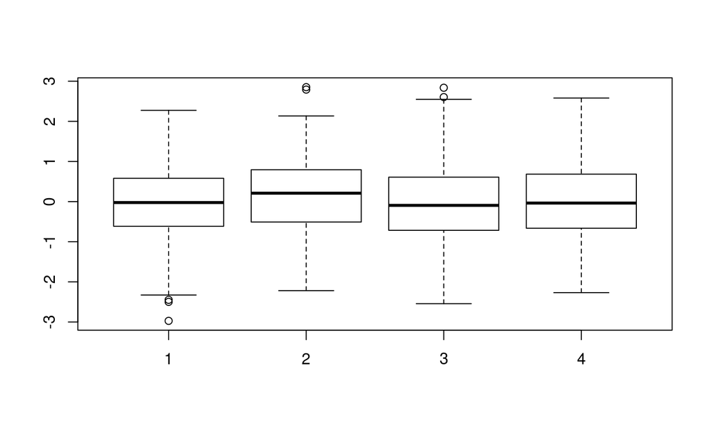

```r
m <- rnorm(800)
m <- matrix(m, ncol = 4)
boxplot(m)
```

## Pipes - piped workflow

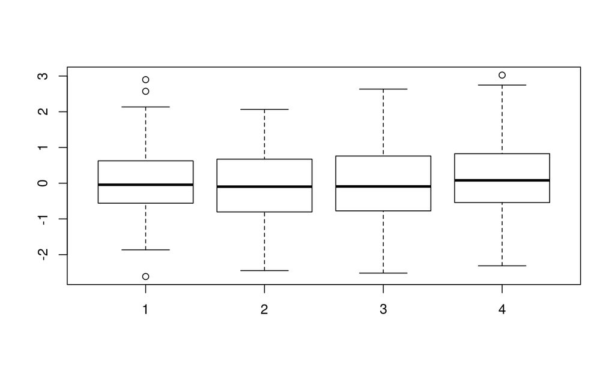

```r
rnorm(800) %>% matrix(ncol = 4) %>% boxplot()
```

## Exkurs dplyr

## Exkurs dplyr - was ist dplyr?

- [dplyr package](https://cran.rstudio.com/web/packages/dplyr/vignettes/introduction.html)
- "It provides simple “verbs”, functions that correspond to the most common data manipulation tasks, to help you translate those thoughts into code."
- unterstützt Piping mit `%>%` \(\rightarrow\) integrierter Workflow

## Exkurs dplyr - dplyr *Verben*

- `filter() (and slice())`: Zeilen auswählen
- `arrange()`: Zeilen anordnen / sortieren
- `select() (and rename())`: Variablen/Spalten auswählen und umbenennen
- `distinct()`: unique Zeilen extrahieren (Dubletten löschen)
- `mutate()`: neue Variablen/Spalten erstellen
- `summarise()`: Werte zusammenfassen
- `group_by`: Operationen nach Gruppen durchführen (z.B. `summarise`)

## Exkurs dplyr - dplyr Beispiel

```r
data(mtcars)
colnames(mtcars)
```

```
##  [1] "mpg"  "cyl"  "disp" "hp"   "drat" "wt"   "qsec" "vs"   "am"   "gear"
## [11] "carb"
```

```r
mtcars %>%
  select(mpg, cyl, am:carb) %>%
  filter(cyl == 6) %>%
  mutate(l100km = (100 * 3.78) / (1.61 * mpg)) %>%
  arrange(desc(l100km))
```

```
##    mpg cyl am gear carb   l100km
## 1 17.8   6  0    4    4 13.19003
## 2 18.1   6  0    3    1 12.97141
## 3 19.2   6  0    4    4 12.22826
## 4 19.7   6  1    5    6 11.91790
## 5 21.0   6  1    4    4 11.18012
## 6 21.0   6  1    4    4 11.18012
## 7 21.4   6  0    3    1 10.97115
```

## dplyr - Aufgabenset 3

1. Für unsere Analyse konzentrieren wir uns auf Fälle, wo der primäre Akteur eine Institution der EU ist (Variable `Actor1Name`).
2. Außerdem benötigen wir nur alle Variablen für Actor 1 und Actor 2, die Eventcode-Variablen, GoldsteinScale sowie die Anzahl der Erwähnungen und der Artikel (Tipp: `?starts_with`).

## Data Manipulation

## Data Manipulation - Faktoren

- Ein factor ist ein Integer-Vektor, der nur vordefinierte Werte annehmen kann
- häufig verwendet, um kategoriale Variablen zu speichern
- "Factors have a bad rap in R because they often turn up when you don’t want them." ([Hadley Wickham auf RStudio Blog](https://blog.rstudio.org/2016/08/31/forcats-0-1-0/))

\(\rightarrow\) wenn möglich, character vectors benutzen

## Data Manipulation - Faktoren

```r
x_fac <- factor(c("a", "b", "b", "a"))
levels(x_fac)
```

```
## [1] "a" "b"
```

- Werte, die nicht Teil der Levels sind, können nicht verwendet werden.

```r
x_fac[2] <- "c"
x_fac
```

```
## [1] a    <NA> b    a
## Levels: a b
```

## Data Manipulation - Faktoren

```r
x_fac <- factor(c("a", "b", "b", "a"))
summary(x_fac)
```

```
## a b
## 2 2
```

```r
x_char <- c("a", "b", "b", "a")
summary(x_char)
```

```
##    Length     Class      Mode
##         4 character character
```

```r
summary(factor(x_char))
```

```
## a b
## 2 2
```

## Data Manipulation - Faktoren

- Levels verändern

```r
levels(x_fac) <- c("c", "d")
x_fac
```

```
## [1] c d d c
## Levels: c d
```

```r
levels(x_fac)[1] <- "e"
x_fac
```

```
## [1] e d d e
## Levels: e d
```

## Data Manipulation - Faktoren

- package [`forcats`](https://blog.rstudio.org/2016/08/31/forcats-0-1-0/)
  - u.a. Rekodierungsfunktion, collapse-Funktion

```r
gss_cat %>%
  mutate(partyid = fct_recode(partyid,
    "Republican, strong"    = "Strong republican",
    "Republican, weak"      = "Not str republican",
    "Independent, near rep" = "Ind,near rep",
    "Independent, near dem" = "Ind,near dem",
    "Democrat, weak"        = "Not str democrat",
    "Democrat, strong"      = "Strong democrat"
  ))
```

## Data Manipulation - Rekodieren von kategorialen Variablen

### Faktoren

- siehe oben

### Character vectors

- `ifelse()`: max. drei Ausprägungen
- über help table

## Data Manipulation - Rekodieren von kategorialen Variablen

- `forcats::fct_recode`

```r
df <- data.frame(x = rep(c("strongly agree", "agree", "neither",
                           "disagree", "strongly disagree"), 2),
                 stringsAsFactors = TRUE)
df_fct <- df %>% mutate(x = as.numeric(fct_recode(x,
                             "1" = "strongly agree",
                             "2" = "agree",
                             "3" = "neither",
                             "4" = "disagree",
                             "5" = "strongly disagree")))

str(df_fct)
```

```
## 'data.frame':    10 obs. of  1 variable:
##  $ x: num  4 1 3 2 5 4 1 3 2 5
```

## Data Manipulation - Rekodieren von kategorialen Variablen

- help table

```r
tmp <- data.frame(x = levels(df$x), x_num = 1:5)
df_ht <- left_join(tmp, df, by = "x")
str(df_ht)
```

```
## 'data.frame':    10 obs. of  2 variables:
##  $ x    : Factor w/ 5 levels "agree","disagree",..: 1 1 2 2 3 3 4 4 5 5
##  $ x_num: int  1 1 2 2 3 3 4 4 5 5
```

## Data Manipulation - Rekodieren von kontinuierlichen Variablen

### in Intervalle einteilen

- Informationsverlust! \(\rightarrow\) don't do it!

### Reskalieren / Logarithmieren

```r
x <- 1:10
x_double <- x * 2
x_log <- log(x)
```

- Vektorisierung!

## Data Manipulation - Aufgabenset 4

1. Die Variable `EventRootCode` enhält den übergeordneten Kategoriecode für das Event. Füge dem Datensatz die entsprechende Beschreibung hinzu. Benutze hierzu den Datensatz `event_codes.xls`.
2. Erstelle eine Variable `dyad`, die die Informationen über beide beteiligten Akteure in jeder Zeile kombiniert. Für Events, in die nicht zwei Akteure involviert sind, setzen wir die Variable auf `NA`.
3. Wandle die Spalte `SQLDATE` in ein R Datum um (`?as.Date` und [diese Website](https://www.stat.berkeley.edu/~s133/dates.html)) und lösche Zeilen mit einem Datum vor dem 1. April diesen Jahres.

## Datenstrukturen und -formate

## Datenstrukturen und -formate - Thinking about your data

> a small, but important, aspect of data cleaning that I call data *tidying*: structuring datasets to *facilitate analysis*. [H.W., tidyr vignette](https://cran.r-project.org/web/packages/tidyr/vignettes/tidy-data.html)

### Fragen

- was sind die Variablen, was die Beobachtungen?
- was für hierarchische Strukturen und Gruppenstrukturen gibt es?
- was für eine Analyse will ich durchführen?
- wie möchte ich meine Daten visualisieren?
- wie müssen meine Daten dafür aussehen?
- …

\(\rightarrow\) häufig mehrere Versionen/Formen der gleichen Daten notwendig! \(\rightarrow\) Flexibilität von R!  
\(\rightarrow\) iterativer Prozess

## Datenstrukturen und -formate - long and wide format

- Paneldaten: wide format

```r
df_wide <- data.frame(name = c("Mary", "John", "Andy"),
                      weight2005 = c(65, 75, 80),
                      weight2006 = c(64, 80, 75))
df_wide
```

```
##   name weight2005 weight2006
## 1 Mary         65         64
## 2 John         75         80
## 3 Andy         80         75
```

## Datenstrukturen und -formate - long and wide format

- Paneldaten: long format

```r
df_long <- data.frame(name = rep(c("Mary", "John", "Andy"), each = 2),
                      year = rep(c(2005:2006), times = 3),
                      weight = c(65, 64, 75, 80, 80, 75))
df_long
```

```
##   name year weight
## 1 Mary 2005     65
## 2 Mary 2006     64
## 3 John 2005     75
## 4 John 2006     80
## 5 Andy 2005     80
## 6 Andy 2006     75
```

## Datenstrukturen und -formate - long and wide format

- Hashtag Ranks nach Account Art

```
##   rank     not_alt         alt
## 1    1      resist      resist
## 2    2  resistance  resistance
## 3    3 trumprussia wearealtgov
```

```
##       hashtag acc_type rank
## 1      resist  not_alt    1
## 2  resistance  not_alt    2
## 3 trumprussia  not_alt    3
## 4      resist      alt    1
## 5  resistance      alt    2
## 6 wearealtgov      alt    3
```

## Datenstrukturen und -formate - long \(\rightarrow\) wide

### reshape

```r
reshape(df_long, v.names = c("weight"),
        idvar = "name", timevar = "year", direction = "wide", sep = "")
```

```
##   name weight2005 weight2006
## 1 Mary         65         64
## 3 John         75         80
## 5 Andy         80         75
```

### tidyr::spread

```r
df_long %>% spread(key = year, value = weight)
```

```
##   name 2005 2006
## 1 Andy   80   75
## 2 John   75   80
## 3 Mary   65   64
```

## Datenstrukturen und -formate - wide \(\rightarrow\) long

### reshape

```r
reshape(df_wide, varying = c("weight2005", "weight2006"),
        idvar = "name", timevar = "year", direction = "long", sep = "")
```

```
##           name year weight
## Mary.2005 Mary 2005     65
## John.2005 John 2005     75
## Andy.2005 Andy 2005     80
## Mary.2006 Mary 2006     64
## John.2006 John 2006     80
## Andy.2006 Andy 2006     75
```

## Datenstrukturen und -formate - wide \(\rightarrow\) long

### tidyr::gather

```r
df_wide %>% gather(key = year, value = weight, weight2005:weight2006)
```

```
##   name       year weight
## 1 Mary weight2005     65
## 2 John weight2005     75
## 3 Andy weight2005     80
## 4 Mary weight2006     64
## 5 John weight2006     80
## 6 Andy weight2006     75
```

## Datenstrukturen und -formate - wide \(\leftrightarrow\) long

### reshape

- explizitere und genauere Spezifizierung
- zwei Sachen in einer Funktion

### gather/spread

- weniger Argumente
- weniger flexibel (siehe year issue)
- zwei separate Funktionen
- bessere Integration in dplyr/tidyr workflow

\(\rightarrow\) Dokumentation genau lesen (RTFM)!

[interactive chart not shown]

## Datenstrukturen und -formate - gruppierte Operationen / summarize

### Fragen revisited

- was für hierarchische Strukturen und Gruppenstrukturen gibt es?
- was für eine Analyse will ich durchführen?
- …

### Beispiel

- Twitter Daten von sogenannten "Alt Accounts" (Hiwi Job bei Prof. Mergel + Jun. Prof. Donnay)

## Datenstrukturen und -formate - Twitter Beispiel

```
## 'data.frame':    16054 obs. of  14 variables:
##  $ usr_id      : chr  "824270573203292160" "824270573203292160" "824270573203292160" "824270573203292160" ...
##  $ screen_name : chr  "ActualEPAFacts" "ActualEPAFacts" "ActualEPAFacts" "ActualEPAFacts" ...
##  $ followers   : int  113355 262049 14632 14722 14714 14834 14825 15012 15123 15171 ...
##  $ follows     : int  49 88 38 38 38 38 38 39 39 39 ...
##  $ status_count: int  330 1103 191 193 192 195 194 196 197 198 ...
##  $ tweet_id    : chr  "824708098216628225" "829298984242016257" "824409033213902853" "824409380414185476" ...
##  $ body        : chr  "@kaclk @altUSEPA We've chatted.  We're okay with it.  Thank you!" "Weather data... Because we're nerds. Pretty cool though. https://t.co/WHVzRzGjcY" "Every single day, 70 million tons of carbon dioxide are released into our world's atmosphere. 1.4 billion pound"| __truncate…
##  $ date        : Date, format: "2017-01-26" "2017-02-08" ...
##  $ retweeted   : chr  "" "" "" "" ...
##  $ mentions    : chr  "['212342280', '824190260338954240']" "[]" "[]" "[]" ...
##  $ hashtags    : chr  "" "" "climatechange" "climatechange,resist" ...
##  $ acctype     : chr  "alt" "alt" "alt" "alt" ...
##  $ is_retweet  : logi  FALSE FALSE FALSE FALSE FALSE TRUE ...
##  $ num_hashtags: num  1 1 1 2 1 1 2 1 1 1 ...
```

## Datenstrukturen und -formate - Twitter Beispiel

- was für hierarchische Strukturen und Gruppenstrukturen gibt es?
  - Tweet
  - Account
  - Tag/Datum
  - Hashtag
  - …
- was für eine Analyse will ich durchführen?
  - wie oft tweeten die unterschiedlichen Accounts? \(\rightarrow\) Tweets (Zeilen) pro Accountname
  - an welchen Tagen wird am meisten getweetet?
  - (wie oft werden welche hashtags verwendet?)

## Datenstrukturen und -formate - Twitter Beispiel

- wie oft tweeten die unterschiedlichen Accounts?

```r
nrow(tweets)
```

```
## [1] 16054
```

- wir brauchen:

```r
length(unique(tweets$screen_name))
```

```
## [1] 39
```

## Datenstrukturen und -formate - Twitter Beispiel

- `dplyr` to the rescue!

```r
tweets_by_acc <- tweets %>%
  group_by(screen_name) %>%
  mutate(ntweets = n())
nrow(tweets_by_acc)
```

```
## [1] 16054
```

```r
summary(tweets_by_acc$ntweets)
```

```
##    Min. 1st Qu.  Median    Mean 3rd Qu.    Max.
##       2     502    1931    1520    2138    2725
```

## Datenstrukturen und -formate - Twitter Beispiel

```r
tweets_by_acc <- tweets %>%
  group_by(screen_name) %>%
  summarize(ntweets = n())
nrow(tweets_by_acc)
```

```
## [1] 39
```

```r
str(tweets_by_acc)
```

```
## Classes 'tbl_df', 'tbl' and 'data.frame':    39 obs. of  2 variables:
##  $ screen_name: chr  "ActualEPAFacts" "Alt_CDC" "Alt_DeptofED" "ALT_DOJ" ...
##  $ ntweets    : int  1931 57 152 289 438 360 2138 87 9 4 ...
```

## Datenstrukturen und -formate - Twitter Beispiel

## Datenstrukturen und -formate - Twitter Beispiel

- an welchen Tagen wird am meisten getweetet? \(\rightarrow\) unterscheiden sich die twitter accounts in ihrer Tweetaktivität über Zeit?

```r
tweets_by_day <- tweets %>%
  group_by(screen_name, date) %>%
  summarize(ntweets = n())
nrow(tweets_by_day)
```

```
## [1] 890
```

```r
str(tweets_by_day)
```

```
## Classes 'grouped_df', 'tbl_df', 'tbl' and 'data.frame':  890 obs. of  3 variables:
##  $ screen_name: chr  "ActualEPAFacts" "ActualEPAFacts" "ActualEPAFacts" "ActualEPAFacts" ...
##  $ date       : Date, format: "2017-01-25" "2017-01-26" ...
##  $ ntweets    : int  10 22 5 2 7 6 7 11 9 6 ...
##  - attr(*, "vars")=List of 1
##   ..$ : symbol screen_name
##  - attr(*, "drop")= logi TRUE
```

## Datenstrukturen und -formate - Twitter Beispiel

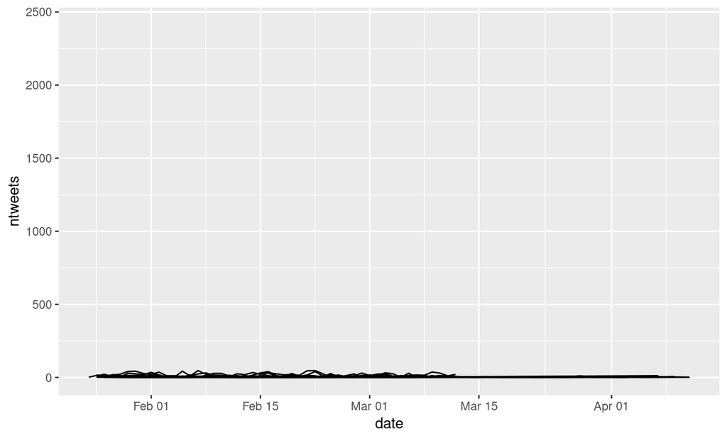

## Datenstrukturen und -formate - Aggregation und Window functions

### Aggregation functions

- `sum()`, `mean()`… (n -> 1)

### Window functions

"A window function is a variation on an aggregation function. Where an aggregation function, like sum() and mean(), takes n inputs and return a single value, a window function returns n values." [dplyr window functions](https://cran.r-project.org/web/packages/dplyr/vignettes/window-functions.html)

## Datenstrukturen und -formate - Twitter Beispiel

- mittlere Anzahl von Hashtags nach Account

```r
mean_ht_by_account <- tweets %>%
  group_by(screen_name) %>%
  summarize(mean_ht = mean(num_hashtags)) %>%
  arrange(desc(mean_ht))
head(mean_ht_by_account, 3)
```

```
## # A tibble: 3 × 2
##     screen_name  mean_ht
##           <chr>    <dbl>
## 1     Rogue_NSF 1.700000
## 2 AltDept_of_VA 1.611765
## 3       altusda 1.397321
```

## Datenstrukturen und -formate - wo sind meine Variablen?

### Problem

- Kombination `group_by + summarize` schmeißt nur Variablen raus, die im `group_by` sind oder die bei `summarize` erstellt werden

### Lösung

- Variablen in `group_by` inkludieren (wichtig: Reihenfolge ggf. beachten)
- Subset des Ausgangsdataframes später mit `left_join` wieder dranmergen

## Datenstrukturen und -formate - Aufgabenset 5

1. Erstelle einen Datensatz, der für jede Eventcode - Überkategorie die Anzahl an Events und die mittlere Anzahl von Artikeln enthält.
2. Erstelle einen Datensatz, der für jede Dyade und jede Eventcode - Überkategorie die Anzahl, den mittleren Goldshtein Score und die Summe an Artikeln enthält.

## Exportieren

## Exportieren von Tabellen

### `stargazer`

- sehr viele voreingestellte Formatierungen
- \(\LaTeX\), HTML & Text

### Microsoft Word?!

- Microsoft Word und auch vergleichbare Freeware kann HTML darstllen bzw. konvertieren
- vielleicht zu \(\LaTeX\) wechseln, wenn man eine quantitaive Hausarbeit schreiben will (**Formeln!**)

### Link: [Stargazer Cheat Sheet](http://jakeruss.com/cheatsheets/stargazer.html)

## Exportieren von Tabellen - Word

### Code in R

```r
data(mtcars)
correlation <- cor(mtcars)
output <- stargazer::stargazer(correlation, type = "html")
writeLines(output, "correlation.html")
```

### Importieren in Word

Einfügen \(\rightarrow\) Objekt \(\rightarrow\) Text aus Datei \(\rightarrow\) *Datei wählen* \(\rightarrow\) Einfügen

## Exportieren von Tabellen - \(\LaTeX\)

```r
data(mtcars)
correlation <- cor(mtcars)
output <- stargazer::stargazer(correlation)
writeLines(output, "correlation.tex")
```

### Importieren in \(\LaTeX\)

- Datei muss im selben Ordner wie die Tex-Datei liegen
- alternativ können Tabellen auch in einen Unterordner gelegt werden und der Pfad muss relativ zur ursprünglichen Datei angegeben werden

```
% Datei leigt im selben Ordner
\include{correlation}
% Datei liegt in einem Unterordner
\include{Tabellen/correlation}
```